# Mini_Project_Danso

Jerri Berry Danso

2025-04-07

## Assignment Introduction

This mini-project explores data from the 2023 Tennessee Educator Survey, with the aim of understanding both the landscape of school responses and teacher satisfaction metrics across the state.

## Load Packages and Read Data

```r
# Load required packages
library(readxl)
library(dplyr)
```

```r
library(ggplot2)
library(janitor)
library(tidyverse)
# Read in the Excel file
data <- read_excel("Teacher_Core_School_Consolidated_Suppressed_2023.xlsx") %>%
  clean_names()
glimpse(data)
```

```
## Rows: 52,272
## Columns: 53
## $ number                                                              <dbl> 1,…
## $ district_id                                                         <dbl> 10…
## $ district                                                            <chr> "A…
## $ school_id                                                           <dbl> 2,…
## $ school                                                              <chr> "A…
## $ response_rate                                                       <dbl> 65…
## $ item                                                                <chr> "T…
## $ old_item                                                            <chr> "T…
## $ topic                                                               <chr> "S…
## $ full_question                                                       <chr> "P…
## $ prompt                                                              <chr> "T…
## $ see_column                                                          <chr> "N…
## $ selected                                                            <dbl> NA…
```

[output cut: 40 more lines]

## Two Questions

### Question 1: What does the overall landscape of the dataset look like?

Specifically:

- How many unique schools are represented in the dataset?
- How many unique school districts?
- What is the distribution of response rates across schools?

```r
# Number of unique schools
num_schools <- data %>%
  distinct(school_id, school) %>%
  nrow()

# Number of unique districts
num_districts <- data %>%
  distinct(district_id, district) %>%
  nrow()

# Response rate summary (top 100)
min_max <- data %>%
  summarize(
    min_rate = min(response_rate, na.rm = TRUE),
    max_rate = max(response_rate, na.rm = TRUE)
  )
response_summary <- data %>%
  select(school, response_rate) %>%
  distinct() %>%
  arrange(desc(response_rate)) %>%
  head(100) %>%
  mutate(
    min_response_rate = min_max$min_rate,
    max_response_rate = min_max$max_rate
  )

# Output the results
list(
  "Number of Unique Schools" = num_schools,
  "Number of Unique Districts" = num_districts,
  "Response Rate (Top 100 Schools)" = response_summary
)
```

```
## $`Number of Unique Schools`
## [1] 964
##
## $`Number of Unique Districts`
## [1] 138
##
## $`Response Rate (Top 100 Schools)`
## # A tibble: 100 × 4
##    school                      response_rate min_response_rate max_response_rate
##    <chr>                               <dbl>             <dbl>             <dbl>
##  1 Community Elementary School           100                45               100
##  2 East Side Elementary                  100                45               100
##  3 Carpenters Middle School              100                45               100
##  4 Townsend Elementary                   100                45               100
##  5 Hampton High School                   100                45               100
##  6 Chester County Middle Scho…           100                45               100
##  7 East Chester Elementary Sc…           100                45               100
##  8 Jacks Creek Elementary                100                45               100
##  9 Bridgeport Elementary                 100                45               100
## 10 The Discovery School                  100                45               100
## # ℹ 90 more rows
```

### Question 2: How do educators respond to two specific items related to school satisfaction?

I focused on the following two items from the `prompt` variable:

- “I would recommend this school to parents seeking a place for their child.”
- “I am generally satisfied with being a teacher in this school.”

```r
# Filter for just the two prompts of interest
focus_items <- data %>%
  filter(prompt %in% c(
    "I would recommend this school to parents seeking a place for their child.",
    "I am generally satisfied with being a teacher in this school."
  )) %>%
  select(number, district_id, district, school_id, school, response_rate,
         item, old_item, topic, full_question, prompt,
         strongly_disagree_14, disagree_15, agree_16, strongly_agree_17)


# Summarize agreement levels
item_summary <- focus_items %>%
  group_by(prompt) %>%
  summarize(
    avg_strongly_agree = mean(strongly_agree_17, na.rm = TRUE),
    avg_agree = mean(agree_16, na.rm = TRUE),
    avg_disagree = mean(disagree_15, na.rm = TRUE),
    avg_strongly_disagree = mean(strongly_disagree_14, na.rm = TRUE)
  )

item_summary
```

```
## # A tibble: 2 × 5
##   prompt         avg_strongly_agree avg_agree avg_disagree avg_strongly_disagree
##   <chr>                       <dbl>     <dbl>        <dbl>                 <dbl>
## 1 I am generall…               44.3      46.0         7.24                  2.47
## 2 I would recom…               46.5      43.4         7.54                  2.62
```

```r
# Add total agree and total disagree at the school level
focus_items <- focus_items %>%
  ungroup() %>%
  mutate(
    total_agree = agree_16 + strongly_agree_17,
    total_disagree = disagree_15 + strongly_disagree_14
  )

glimpse(focus_items)
```

```
## Rows: 1,936
## Columns: 17
## $ number               <dbl> 2, 3, 2, 3, 2, 3, 2, 3, 2, 3, 2, 3, 2, 3, 2, 3, 2…
## $ district_id          <dbl> 10, 10, 10, 10, 10, 10, 10, 10, 10, 10, 10, 10, 1…
## $ district             <chr> "Anderson County", "Anderson County", "Anderson C…
## $ school_id            <dbl> 2, 2, 3, 3, 5, 5, 15, 15, 20, 20, 25, 25, 35, 35,…
## $ school               <chr> "Anderson County High School", "Anderson County H…
## $ response_rate        <dbl> 65, 65, 67, 67, 90, 90, 75, 75, 84, 84, 54, 54, 8…
## $ item                 <chr> "TC_01c", "TC_01d", "TC_01c", "TC_01d", "TC_01c",…
## $ old_item             <chr> "TC_01c", "TC_01d", "TC_01c", "TC_01d", "TC_01c",…
## $ topic                <chr> "School Climate", "School Climate", "School Clima…
## $ full_question        <chr> "Please indicate the extent to which you agree or…
## $ prompt               <chr> "I am generally satisfied with being a teacher in…
## $ strongly_disagree_14 <dbl> 3, 3, 0, 0, 5, 5, 4, 0, 0, 0, 0, 0, 0, 0, 5, 0, 0…
## $ disagree_15          <dbl> 3, 9, 9, 0, 0, 0, 26, 38, 0, 6, 3, 14, 0, 0, 0, 5…
## $ agree_16             <dbl> 38, 35, 18, 18, 41, 36, 39, 42, 44, 47, 69, 63, 5…
## $ strongly_agree_17    <dbl> 56, 53, 73, 82, 55, 59, 30, 21, 56, 47, 29, 23, 5…
## $ total_agree          <dbl> 94, 88, 91, 100, 96, 95, 69, 63, 100, 94, 98, 86,…
## $ total_disagree       <dbl> 6, 12, 9, 0, 5, 5, 30, 38, 0, 6, 3, 14, 0, 0, 5, …
```

```r
# Summarize min, max, and average of total_agree by prompt
agreement_summary <- focus_items %>%
  group_by(prompt) %>%
  summarize(
    min_agree = min(total_agree, na.rm = TRUE),
    max_agree = max(total_agree, na.rm = TRUE),
    avg_agree = mean(total_agree, na.rm = TRUE)
  )

agreement_summary
```

```
## # A tibble: 2 × 4
##   prompt                                           min_agree max_agree avg_agree
##   <chr>                                                <dbl>     <dbl>     <dbl>
## 1 I am generally satisfied with being a teacher i…        33       101      90.3
## 2 I would recommend this school to parents seekin…        20       101      89.9
```

To explore educator sentiment, I focused on two survey items related to school satisfaction:

- “I would recommend this school to parents seeking a place for their child.”
- “I am generally satisfied with being a teacher in this school.”

While these items are not comprehensive measures of school quality or teacher morale, they serve as useful indicators of how educators feel about their work environment. The recommendation item, in particular, is a strong proxy for trust and satisfaction. Teachers are unlikely to recommend a school to families unless they have confidence in its leadership, culture, and overall quality. Likewise, general satisfaction with being a teacher at the school can serve as a broad measure of morale.

I combined the “Agree” and “Strongly Agree” response options to reflect positive sentiment. For the recommendation item, the total agreement ranged from 20% to 101%, while the general satisfaction item ranged from 33% to 101%. The 101% values are likely due to rounding in percentage calculations. On average, agreement levels for both items were around 90%, suggesting that most educators reported strong positive feelings about their schools.

## Visualization

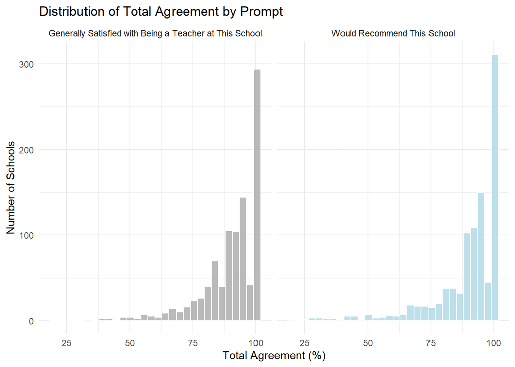

```r
#Rename prompt for shorter graph labels
prompt_labels <- c(
  "I would recommend this school to parents seeking a place for their child." = "Would Recommend This School",
  "I am generally satisfied with being a teacher in this school." = "Generally Satisfied with Being a Teacher at This School"
)

# Faceted histograms of total_agree by prompt
ggplot(focus_items, aes(x = total_agree, fill = prompt)) +
  geom_histogram(bins = 30, color = "white", alpha = 0.8) +
  scale_fill_manual(values = c(
    "I would recommend this school to parents seeking a place for their child." = "lightblue",
    "I am generally satisfied with being a teacher in this school." = "darkgray"
  )) +
  facet_wrap(~ prompt, labeller = labeller(prompt = prompt_labels)) +
  labs(
    title = "Distribution of Total Agreement by Prompt",
    x = "Total Agreement (%)",
    y = "Number of Schools"
  ) +
  theme_minimal() +
  theme(legend.position = "none")
```

The histograms show the distribution of total agreement (i.e., combined “Agree” and “Strongly Agree” responses) across schools for each of the two satisfaction-related survey items. Both distributions are skewed toward higher agreement levels, with most schools reporting over 80% agreement. This suggests that, overall, educators tend to have positive perceptions of their schools and teaching experiences.

## Reflection

This mini project provided a valuable opportunity to apply and reinforce concepts I’ve been developing throughout the semester, particularly in the areas of data wrangling, visualization, and interpretation using R. I also drew on skills from my previous coursework in the fall, particularly those involving ggplot2. The process of selecting meaningful survey items, cleaning the data, and building clear, informative visualizations helped deepen my understanding of how to communicate insights effectively. While my code worked well overall, I recognized areas where I could have written more efficient, less repetitive code (a goal I will continue to work toward as I grow more comfortable with R).

The dataset from the Tennessee Department of Education was both rich and engaging. Even though I focused on just two prompts, the process sparked curiosity about the full range of survey items and how responses might vary across contexts. It would be fascinating to explore whether educator sentiments differ significantly by district or school type (elementary, middle, or high school), and whether particular districts exhibit notably higher or lower satisfaction trends.